# Aula 03 - Conhecendo seus Dados

Métodos Quantitativos Aplicados à Ciência Política

Frederico Bertholini

# Vetores

## O que são vetores?

- Vetores são combinações de valores em uma estrutura unidimensional
- Ou seja, podem ser combinações de números, valores lógicos, nomes e várias outras possibilidades
- Por exemplo, combinação de valores pares: 2,4,6,8
- Ou a combinações de nomes começando por P: Pedro, Paula, Pietro, Paloma
- Combinação de valores lógico: TRUE, FALSE, TRUE, TRUE

## Criação de vetores

- Para criar vetores é importante combinar valores
- A função necessária para a criação de vetores é a função c(), c de *combine* ou *concatenate*

```r
c(2,4,6,8)
```

```
[1] 2 4 6 8
```

```r
c("Pedro","Paula","Pietro","Paloma")
```

```
[1] "Pedro"  "Paula"  "Pietro" "Paloma"
```

```r
c(TRUE,FALSE,TRUE,FALSE)
```

```
[1]  TRUE FALSE  TRUE FALSE
```

## Etiquetas para vetores

- Assim como fizemos com os valores, atribuímos também etiquetas aos vetores
- Dessa maneira, podemos trabalhar com as sequências ao longo do script, assim como dar razão ou justificativa aos valores combinados

```r
n.pares <- c(2,4,6,8)

nomes.com.p <-
c("Pedro","Paula","Pietro","Paloma")

valores.log <- c(TRUE,FALSE,TRUE,FALSE)
```

## Classes dos vetores

- Os vetores também possuem classes
- Essas categorias determinam as operações possíveis dentro de um vetor
- Para obter a informação sobre a classe de um vetor, utilizamos a função class()

```r
class(n.pares)
```

```
[1] "numeric"
```

```r
class(nomes.com.p)
```

```
[1] "character"
```

```r
class(valores.log)
```

```
[1] "logical"
```

## Comprimento de vetores

- Os vetores podem ser medidos em relação ao seu comprimento
- O seu comprimento define a extensão do vetor, assim como quantos elementos estão presentes dentro da combinação de valores
- O comprimento pode ser medido pela função length()

```r
length(n.pares)
```

```
[1] 4
```

```r
length(nomes.com.p)
```

```
[1] 4
```

```r
length(valores.log)
```

```
[1] 4
```

## Somatório de vetores

- Para vetores númerico podemos somar os valores de um vetor
- A função se chama sum() que corresponde ao $\sum$

```r
sum(n.pares)
```

```
[1] 20
```

- Em vetores com valores lógicos, com TRUE e FALSE, o sum soma o número de T que temos dentro de um vetor

```r
sum(valores.log)
```

```
[1] 2
```

## Somatório de vetores lógicos

- A função sum() pode se tornar ainda um contador de um teste
- Por exemplo, queremos saber quantos nomes são iguais ao de Pedro no vetor ‘nomes.com.p’

```r
teste1 <- nomes.com.p == "Pedro"

sum(teste1)
```

```
[1] 1
```

```r
teste1
```

```
[1]  TRUE FALSE FALSE FALSE
```

## Seleção de elementos

- Queremos selecionar no vetor nomes.com.p o segundo elemento que é Paula
- Vejamos, primeiro, como se compõe o vetor de caracteres nomes.com.p e a lógica do posicionamento dentro do vetor

```r
nomes.com.p
```

```
[1] "Pedro"  "Paula"  "Pietro" "Paloma"
```

## Usando `%in%` na Seleção de elementos

- Vamos testar se Paula se inclui dentro do vetor sem termos que ver no console
- As vezes, vetores são maiores do que temos como exemplo
- Para o teste lógico, utilizamos o operador %in%, que retorna TRUE, caso o valor esteja incluso no vetor

```r
"Paula" %in% nomes.com.p
```

```
[1] TRUE
```

## Regras de Seleção de elementos

- Algumas operações se restrigem a determinados elementos ou a um conjunto deles incluso dentro de um vetor
- Para realizar tais procedimentos precisamos saber escolher elementos
- Para isso, utilizaremos o operador ‘[]’ depois de apontar o vetor
- Mais especificamente: Vetor; []; Posição ou regra;

## Alternativas de Seleção 1

- Para escolhar Paula, portanto, vamos definir como a segunda posição dentro do vetor

```r
nomes.com.p[2]
```

```
[1] "Paula"
```

- O posicionamento dos nomes ao longo do vetor determina como seleciona-lo individualmente
- Porém, podemos selecionar através do valor

```r
nomes.com.p[nomes.com.p == "Paula"]
```

```
[1] "Paula"
```

## Alternativas de Seleção 2

- Selecionamos também o último valor do vetor nomes.com.p
- Sabemos que o vetor possui 4 valores utilizando a função length()

```r
length(nomes.com.p)
```

```
[1] 4
```

## Alternativas de Seleção 3

- Assim o último valor é igual a 4
- Para selecionarmos o último valor, ou definimos como a posição 4 ou apenas o length() do vetor

```r
nomes.com.p[4]
```

```
[1] "Paloma"
```

```r
nomes.com.p[length(nomes.com.p)]
```

```
[1] "Paloma"
```

## Seleção de elementos

- Para seleção de elementos através de regras, podemos utilizar o vetor númerico de n.pares

```r
n.pares  <- c(2,4,6,8)

n.pares
```

```
[1] 2 4 6 8
```

- O objetivo aqui é selecionar os elementos maiores que 5, que é a mediana do vetor

```r
median(n.pares)
```

```
[1] 5
```

## Seleção de elementos

- Selecionamos, assim, os elementos acima da mediana do vetor n.pares, que são os valores 6 e 8

```r
n.pares[n.pares > 5]
```

```
[1] 6 8
```

- Ou ainda podemos definir o valor 5 como o valor da mediana
- O resultado é o mesmo, porém, deixa claro ao leitor do seu script que se trata dos valores acima da mediana do vetor n.pares

```r
n.pares[n.pares > median(n.pares)]
```

```
[1] 6 8
```

# Operações matemáticas

## Operações com vetores

- Em vetores numéricos, podemos fazer operações matemáticas a partir do seu posicionamento
- Vamos calcular o alcance do vetor “n.pares”

```r
#ultimo elemento
n.pares[length(n.pares)]
```

```
[1] 8
```

```r
#primeiro elemento
n.pares[1]
```

```
[1] 2
```

- Subtraindo esses dois elementos, temos o alcance do vetor

```r
n.pares[length(n.pares)] - n.pares[1]
```

```
[1] 6
```

## Operações com vetores

- Ainda em vetores numéricos, vamos calcular vetores com regras
- Selecionamos elementos maiores que 5

```r
n.pares[n.pares >= 5]
```

```
[1] 6 8
```

- Queremos duplicar os valores inclusos dentro da condição

```r
n.pares[n.pares >= 5] * 2
```

```
[1] 12 16
```

- Por fim, operacionar um conjunto com um elemento

```r
n.pares[n.pares >= 5] * n.pares[1]
```

```
[1] 12 16
```

## Conjuntos

- Utilizamos a teoria de conjuntos no R com a função de manipular e identificar elementos comuns ou diferente entre vetores
- Já temos o vetor “n.pares” e vamos criar um vetor com números naturais

```r
n.naturais <- c(0,1,2,3,4,5,6,7,8,9)
n.naturais
```

```
 [1] 0 1 2 3 4 5 6 7 8 9
```

- Se perguntarmos por valores que não estão no vetor “n.naturais”, o resultado será conjunto vazio

```r
n.naturais[n.naturais == 10]
```

```
numeric(0)
```

## Conjuntos

- Outro ponto importante é saber se os elementos estão contidos dentro de outro vetor
- A pergunta a se fazer é: os elementos do vetor “n.partidos” está contido no vetor “n.naturais”
- No R, contidos é igual a %in%

```r
n.pares %in% n.naturais
```

```
[1] TRUE TRUE TRUE TRUE
```

## Conjuntos

- Isto é, o vetor “n.pares” está contido no vetor “n.naturais” e é um subconjunto
- Outra maneira é utilizando a função is.element()

```r
is.element(n.pares,n.naturais)
```

```
[1] TRUE TRUE TRUE TRUE
```

## Conjuntos

- Para encontrar os valores exclusivos de um conjunto, vamos utilizar a escrita da seleção de elementos
- Podemos incluir a notação de “!”, que quer dizer diferente
- Portanto, selecionamos os valores que estão contido no conjunto dos naturais, porém não no conjunto dos valores pares

```r
n.naturais[!is.element(n.naturais,n.pares)]
```

```
[1] 0 1 3 5 7 9
```

## Conjuntos

- Por fim, vamos testar se um valor está presente em um desses vetores
- Testaremos os valores 1, 11 e 21

```r
1 %in% c(n.naturais,n.pares)
```

```
[1] TRUE
```

```r
11 %in% c(n.naturais,n.pares)
```

```
[1] FALSE
```

```r
21 %in% c(n.naturais,n.pares)
```

```
[1] FALSE
```

- Assim, não temos os valores 11 e 21 em nenhum dos vetores, entendidos como conjuntos

# data.frame

## data.frame

- Um `data.frame` é o mesmo que uma tabela do SQL ou uma planilha Excel
- seus dados provavelmente serão importados para um objeto data.frame
- data.frame’s são listas especiais em que todos os elementos possuem o mesmo comprimento.
- Cada elemento dessa lista pode ser pensado como uma coluna da tabela - ou como uma variável. Uso do ‘$’
- Seu comprimento representa o número de linhas - ou seja, de observações

## Estrutura de dados - data.frame

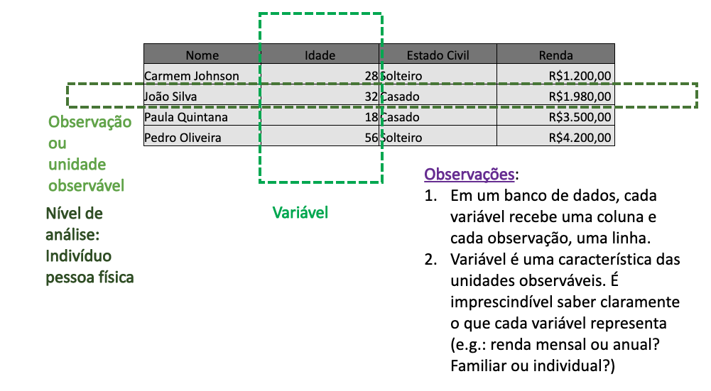

## data.frame de perto

- Como data.frames’s são listas, suas colunas podem ser de classes diferentes. Essa é a grande diferença entre data.frame’s e matrizes.

Funções úteis:

```r
head() # Mostra as primeiras 6 linhas.
tail() # Mostra as últimas 6 linhas.
dim() # Número de linhas e de colunas.
names() # Os nomes das colunas (variáveis).
str() # Estrutura do data.frame. Mostra, entre outras coisas, as >classes de cada coluna.
cbind() # Acopla duas tabelas lado a lado.
rbind() # Empilha duas tabelas.
```

# Pacotes

## O que são pacotes

- O R possui diversas funções já instaladas dentro da sua programação
- Exemplos são sum(), length(), class(), c()
- Outras, porém, devem ser instaladas para que possam ser utilizadas pelos usuários
- A maneira com a qual instalamos novas funções, não definidas anteriormente no software, é através de pacotes
- Pacotes concentram diversas funções para diversas demandas  
  Importação de dados;  
  Organização de banco de dados;  
  Análises estatísticas específicas;  
  Gráficos diferenciados;

## O que são pacotes

- A instalação de qualquer pacote pode ser feita por dentro do R
- Para isso, porém, é preciso primeiro conexão com a internet, já que o R busca o novo pacote no repositório de pacotes
- A função para instalar pacote, portanto, é install.packages()
- O nome da nova função deve vir, primeiramente entre parenteses
- Podemos começar instalando o pacote para importação de bases de dados: foreign

```r
install.packages("foreign")
```

- Após alguns segundos, e algumas mensagens no console, a instalação será efetivada

## Ativar pacotes

- Cada pacote, inclusive o foreign, tem uma documentação disponível na internet
- Nessa documentação estão disponíveis as funções que o pacote possui, além do nome do seu criador
- As função não ficam disponíveis assim que o pacote termina a instalação
- Para ativar as funções do pacote, é preciso utilizar a função library()

```r
library(foreign)
```

- Repare, que uma vez instalado, o nome do pacote não precisa mais estar entre aspas

## Ativar pacotes

- Portanto, para começarmos o procedimento de instalação do pacote, seguimos os passos a seguir:  
  Caso não esteja instalado, instalar o pacote através da função install.packages();  
  Para ativar o pacote, utilizar a função library() sem as aspas no nome do pacote instalado

```r
install.packages("foreign")

library(foreign)
```

- Uma vez instalado o pacote, não é preciso instalar mais a não ser que você reinstale o R

# Importação de dados

## Passo a passo

- A importação é uma das tarefas que demandam mais atenção no R
- É preciso ter um conhecimento prévio de como sua base externa está constituída
- Outra informação importante é a extensão do arquivo da base
- Primeiramente, a informação que deve ser dada ao software é onde está a base - diretório de trabalho

## Passo a passo

- A função necessária é setwd() que define o diretório da sua seção no R
- Dentro da função, iremos inserir o local do arquivo  
  Em caso de Windows, inverta as barras ou duplique;  
  Não se esqueça das aspas;

```r
setwd("/Volumes/Macintosh HD/MQCP_IPOL_2020/Slides/aula 03") # mmudando meu direto
```

## Passo a passo

- Esse diretório definido significa que as bases e os gráficos produzidos serão enviados para essa pasta
- Finalmente, vamos importar as bases de dados
- Primeiro, vamos importar a base de extensão txt com o nome baserm
- Não é preciso de pacote para esse procedimento

## Passo a passo

```r
lines <- readLines("dados/baserm.txt")

baserm <- read.table(text = lines, sep = '\t')
```

- Repare que definimos a base dentro das aspas e com a extensão
- Na segunda linha, o primeiro argumento é o texto, o segundo argumento trata de como os dados estão separados, geralmente txt vem separado assim

## Passo a passo

- No pacote foreign, a forma mais genérica de importação da base é o read.table()
- Entretanto, o pacote apresenta uma série de especialidades, a depender da extensão em questão
- Para CSV, vimos que tem a read.csv(). Já para dta, base de origem do stata, temos a função read.dta()
- O pacote foreign não possui a extensão xlsx e xls, extensão muito encontrada e comum entre as bases de dados disponíveis

## Passo a passo

- Para isso, vamos instalar um novo pacote readxl

```r
install.packages("readxl")
```

- Esse pacote disponibiliza as funções read_xls() e read_xlsx()

## Passo a passo

- Vamos ativar as funções disponíveis no pacote readxl com a função library()

```r
library(readxl)
```

- Vamos importar a base controle_cgu_municípios.xlsx

```r
cgu <-
read_xlsx("dados/controle_cgu_municípios.xlsx")
```

- Repare que acessamos apenas a primeira página da base

## Passo a passo

- Para acessarmos a segunda páginas, utilizamos o argumento sheet=2

```r
cgu <-
read_xlsx("dados/controle_cgu_municípios.xlsx",
sheet = 2)
```

- Alguns sinais de alerta surgem, porém não se trata de erro

## Importação por pacote

- Por fim, podemos importar dados através de pacotes
- Após ativar o pacote “ElectionsBR”, a função legend_fed() fica disponível para a importação
- Como toda a função, ou quase todas, possui argumentos importantes:
  - ‘year =’ se refere ao ano de extração
  - ‘uf =’ se refere à UF

## Importação

- Vamos começar importando dados de coalizões pré-eleitorais (coligações) do DF em 2018, nos retornando um objeto em ‘tbl_df’ e data frame

```r
library(electionsBR)
leg_df_2018 <- legend_fed(year = 2018,uf="DF")
```

[output not shown]

## Visualizando a base

- Primeira coisa importante de se informar é a classe desses objetos
- Temos 3 objetos: baserm, cgu e leg_df_2018

```r
class(baserm)
```

```
[1] "data.frame"
```

```r
class(cgu)
```

```
[1] "tbl_df"     "tbl"        "data.frame"
```

```r
class(leg_df_2018)
```

```
[1] "tbl_df"     "tbl"        "data.frame"
```

## Visualizando a base

- Uma visão completa da base é o comando View()
- Entretanto, cuidado, dependendo do tamanho da base, podemos travar o software

```r
View(leg_df_2018)
```

- Repare no V maiúsculo, lembre-se que o R é bastante sensível na sua linguagem
- O View() abre uma nova aba com a base no formato de grade
- Podemos, assim, visualizar a base de dados na forma mais intuitiva

## Visualizando a base

- Porém, para bases grandes, sabemos que é grande demais para sua visualização ser feita através do View()
- Algumas funções podem nos ajudar nessa tarefa
- A primeira é o dim, que as dimensões da base

```r
dim(leg_df_2018)
```

```
[1] 251  23
```

- O primeiro valor sempre retrata o número de linhas, ou observações, enquanto o segundo valor apresenta o número de colunas, ou variáveis
- As funções ncol() e length() também fazem isso

## Visualizando a base

- Outra função importante na visualização de bases de dados é a lista de nomes
- A função names() descreve as variáveis presentes na base
- Isso facilita no momento de selecionar as variáveis que entrarão na análise de vocês

```r
names(leg_df_2018)
```

```
 [1] "DT_GERACAO"              "HH_GERACAO"
 [3] "ANO_ELEICAO"             "CD_TIPO_ELEICAO"
 [5] "NM_TIPO_ELEICAO"         "NR_TURNO"
 [7] "CD_ELEICAO"              "DS_ELEICAO"
 [9] "DT_ELEICAO"              "SG_UF"
[11] "SG_UE"                   "NM_UE"
[13] "CD_CARGO"                "DS_CARGO"
[15] "TP_AGREMIACAO"           "NR_PARTIDO"
[17] "SG_PARTIDO"              "NM_PARTIDO"
[19] "SQ_COLIGACAO"            "NM_COLIGACAO"
[21] "DS_COMPOSICAO_COLIGACAO" "CD_SITUACAO_LEGENDA"
[23] "DS_SITUACAO"
```

## Visualizando a base - `str()`

- Outra função possível é o str()
- Essa função apresenta o nome das variáveis, a classe de cada uma delas e os primeiros valores

```r
str(leg_df_2018)
```

```
tibble [251 × 23] (S3: tbl_df/tbl/data.frame)
 $ DT_GERACAO             : chr [1:251] "31/03/2024" "31/03/2024" "31/03/2024" "31/03/2024" ...
 $ HH_GERACAO             : 'hms' num [1:251] 11:01:09 11:01:09 11:01:09 11:01:09 ...
  ..- attr(*, "units")= chr "secs"
 $ ANO_ELEICAO            : num [1:251] 2018 2018 2018 2018 2018 ...
 $ CD_TIPO_ELEICAO        : num [1:251] 2 2 2 2 2 2 2 2 2 2 ...
 $ NM_TIPO_ELEICAO        : chr [1:251] "ELEIÇÃO ORDINÁRIA" "ELEIÇÃO ORDINÁRIA" "ELEIÇÃO ORDINÁRIA" "ELEIÇÃO ORDINÁRIA" ...
 $ NR_TURNO               : num [1:251] 1 1 1 1 1 1 1 1 1 1 ...
 $ CD_ELEICAO             : num [1:251] 297 297 297 297 297 297 297 297 297 297 ...
 $ DS_ELEICAO             : chr [1:251] "Eleições Gerais Estaduais 2018" "Eleições Gerais Estaduais 2018" "Eleições Gerais Estaduais 2018" "Eleições Gerais Estaduais 2018" ...
 $ DT_ELEICAO             : chr [1:251] "07/10/2018" "07/10/2018" "07/10/2018" "07/10/2018" ...
 $ SG_UF                  : chr [1:251] "DF" "DF" "DF" "DF" ...
 $ SG_UE                  : chr [1:251] "DF" "DF" "DF" "DF" ...
 $ NM_UE                  : chr [1:251] "DISTRITO FEDERAL" "DISTRITO FEDERAL" "DISTRITO FEDERAL" "DISTRITO FEDERAL" ...
 $ CD_CARGO               : num [1:251] 3 6 6 5 3 9 9 10 4 5 ...
 $ DS_CARGO               : chr [1:251] "GOVERNADOR" "DEPUTADO FEDERAL" "DEPUTADO FEDERAL" "SENADOR" ...
 $ TP_AGREMIACAO          : chr [1:251] "COLIGAÇÃO" "COLIGAÇÃO" "PARTIDO ISOLADO" "COLIGAÇÃO" ...
 $ NR_PARTIDO             : num [1:251] 44 90 29 18 31 10 54 31 45 10 ...
 $ SG_PARTIDO             : chr [1:251] "PRP" "PROS" "PCO" "REDE" ...
 $ NM_PARTIDO             : chr [1:251] "PARTIDO REPUBLICANO PROGRESSISTA" "PARTIDO REPUBLICANO DA ORDEM SOCIAL" "PARTIDO DA CAUSA OPERÁRIA" "REDE SUSTENTABILIDADE" ...
 $ SQ_COLIGACAO           : num [1:251] 7e+10 7e+10 7e+10 7e+10 7e+10 ...
 $ NM_COLIGACAO           : chr [1:251] "BRASÍLIA ACIMA DE TUDO" "RENOVAR DF 2" "#NULO#" "Brasília de Mãos Limpas" ...
 $ DS_COMPOSICAO_COLIGACAO: chr [1:251] "PRP / PRTB" "PROS / PMB / PMN" "PCO" "PSB / PV / PC do B / PDT / REDE" ...
 $ CD_SITUACAO_LEGENDA    : chr [1:251] "D" "D" "IR" "D" ...
 $ DS_SITUACAO            : chr [1:251] "DEFERIDO" "DEFERIDO" "INDEFERIDO COM RECURSO" "DEFERIDO" ...
 - attr(*, ".internal.selfref")=<externalptr>
```

## Visualizando a base - `head()`

- Finalmente, a função head() e tail()
- A primeira função apresenta os primeiros valores de uma base de dados

```r
head(leg_df_2018,2)
```

```
# A tibble: 2 × 23
  DT_GERACAO HH_GERACAO ANO_ELEICAO CD_TIPO_ELEICAO NM_TIPO_ELEICAO   NR_TURNO
  <chr>      <time>           <dbl>           <dbl> <chr>                <dbl>
1 31/03/2024 11:01:09          2018               2 ELEIÇÃO ORDINÁRIA        1
2 31/03/2024 11:01:09          2018               2 ELEIÇÃO ORDINÁRIA        1
# ℹ 17 more variables: CD_ELEICAO <dbl>, DS_ELEICAO <chr>, DT_ELEICAO <chr>,
#   SG_UF <chr>, SG_UE <chr>, NM_UE <chr>, CD_CARGO <dbl>, DS_CARGO <chr>,
#   TP_AGREMIACAO <chr>, NR_PARTIDO <dbl>, SG_PARTIDO <chr>, NM_PARTIDO <chr>,
#   SQ_COLIGACAO <dbl>, NM_COLIGACAO <chr>, DS_COMPOSICAO_COLIGACAO <chr>,
#   CD_SITUACAO_LEGENDA <chr>, DS_SITUACAO <chr>
```

- O segundo argumento serve para indicar quantas linhas serão apresentadas

## Visualizando a base - `head()`

- Tail(), por outro lado, apresenta os últimos valores de uma base de dados

```r
tail(leg_df_2018,2)
```

```
# A tibble: 2 × 23
  DT_GERACAO HH_GERACAO ANO_ELEICAO CD_TIPO_ELEICAO NM_TIPO_ELEICAO   NR_TURNO
  <chr>      <time>           <dbl>           <dbl> <chr>                <dbl>
1 31/03/2024 11:01:09          2018               2 ELEIÇÃO ORDINÁRIA        1
2 31/03/2024 11:01:09          2018               2 ELEIÇÃO ORDINÁRIA        1
# ℹ 17 more variables: CD_ELEICAO <dbl>, DS_ELEICAO <chr>, DT_ELEICAO <chr>,
#   SG_UF <chr>, SG_UE <chr>, NM_UE <chr>, CD_CARGO <dbl>, DS_CARGO <chr>,
#   TP_AGREMIACAO <chr>, NR_PARTIDO <dbl>, SG_PARTIDO <chr>, NM_PARTIDO <chr>,
#   SQ_COLIGACAO <dbl>, NM_COLIGACAO <chr>, DS_COMPOSICAO_COLIGACAO <chr>,
#   CD_SITUACAO_LEGENDA <chr>, DS_SITUACAO <chr>
```

IPOL/UnB